# Twilio

Project for BYU-Idaho Communications.

Author

Daniel Dominguez

## Project Overview

This project aimed to provide my supervisor with a comprehensive understanding of the costs associated with messaging generated by each department at BYU-Idaho. The primary goal was to visualize these costs in a user friendly dashboard, breaking down the number of messages sent, the associated fees, and the types and frequency of errors returned by the serer. Another key objective was to analyze opt-out patterns, particularly in relation to specific departments’ communications, helping identify areas where student opting out was happening.

## Challenges and Constraints

The dashboard required integrating data from three separate datasets:

- Message Log Dataset: This dataset captured all sent and received text messages. Initially, this was a manual process, but we later automated it by establishing a connection to the Twilio API and storing the data in a database that could be periodically updated.
- Invoice Dataset: The dataset included all the charges incurred by the university. Unfortunately, there was no API available, so the data had to be manually extracted as a CSV file each month. This dataset was particularly challenging to work with due to duplicated data, mismatched formatting between the CSV and PDF versions of the invoice, and inconsistencies in the fee breakdowns, such as taxes and processing fees not being included in the message log.
- Phone Number and Department Dataset: This dataset was maintained in an Excel file and contained the frequently used phone numbers across departments. The file allowed updates through Microsoft Teams, ensuring accuracy in linking phone numbers to their respective departments.

### Key Issues

Integrating the datasets presented several challenges:

- The price data from the message log did not account for additional fees and taxes applied in the invoice.
- Message counts from the log did not match invoice totals, requiring extensive data wrangling to clean duplicates and standardize entries.
- There was no shared key between the log and invoice datasets, making it difficult to reconcile the data across systems.

## Data Wrangling and Integration Process

To tackle these issues, I implemented the following strategies:

- Price Adjustment Column: I calculated the true message costs by creating a column in the log data that incorporated additional fees and taxes from the invoice. For this, I created a new measure using DAX to represent the messages as a percentage of the total costs, allowing me to allocate the invoice costs accurately to each department.
- Message Count Alignment: Cleaning the duplicate entries and standardizing message counts helped match numbers between the datasets, providing a more accurate reflection of costs.
- Establishing a Surrogate Key: I created a surrogate key using the year and month from the invoice, linking it to the message data. This allowed us to synchronize the messages with the correct month of the invoice and establish communication between the datasets.
- Error Tracking: The errors encountered during message delivery were tracked using Twilio error codes. I created a lookup table to decode these error codes, giving departments insights into why students might be opting out and which errors were contributing to unnecessary costs.

Here is how the connection look between all the tables after I finished doing the wrangling

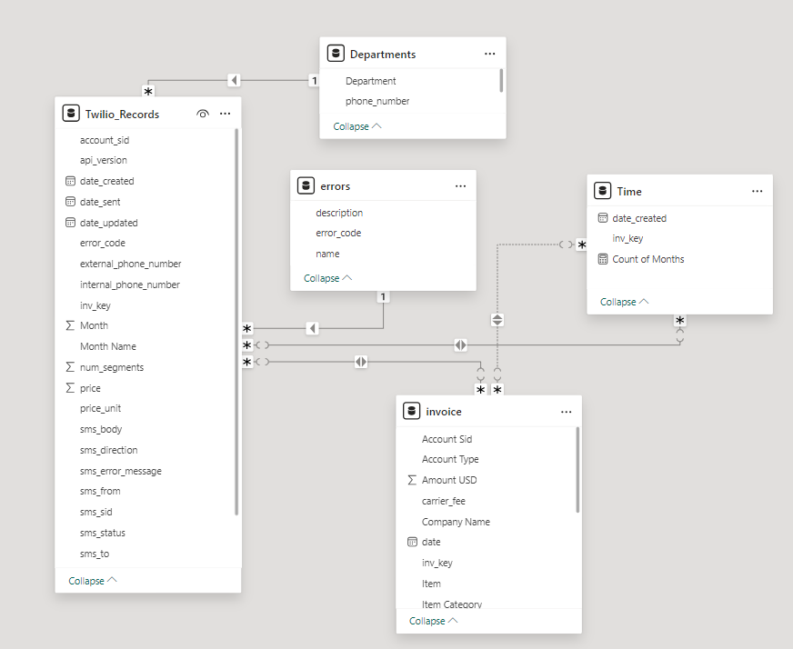

image

## The Dashboard

The dashboard consists of four pages, one of the most important features are the slicers that provide dig to the most specific details of the searches that my supervisor wantanded. Each of the pages provices an specific view of the messaging data and the quesitons we had to answer:

**Page 1: Cost Summary by Account**  
This page presents a high-level overview of the total costs for each of BYU-Idaho’s Twilio accounts. It includes:

- Total cost per account, broken down by month and year.
- Taxes and fees applied to each account, offering clarity on how charges accumulate over time.

To create this view, I linked the message log with the invoice data by the year and month, allowing us to track how much each department was spending monthly, inclusive of tax and processing fees.

[figure not shown]

**Page 2: Departmental Messaging and Cost Breakdown**  
This page focuses on departmental performance, detailing:

- The number of messages sent and received by each department.
- A breakdown of the cost after fees per department.
- The percentage of total messaging costs that each department accounts for.

I calculated the percentage of the total cost per department by creating a measure to multiply the total invoice by the department’s share of messages, helping us accurately allocate costs. The DAX measure I created was crucial in making this percentage calculation, ensuring an even distribution of fees.

[figure not shown]

The error data was pulled in through the Twilio API, and I matched error codes with the message logs to pinpoint which departments were causing issues. I also generated a list of phone numbers that had opted out, which helped departments better understand engagement challenges.

[figure not shown]

This page is particularly useful for tracking opt-out reasons, as it allowed us to investigate if the content of certain messages was driving users away. I built search functionality within this slide to trace specific phone numbers and understand their message history.

[figure not shown]

Back to top